# From zero to hero: raw data to mapped networks - 1 Preprocessing

##### Check out the [user manual](https://creativedatasolutions.github.io/dave.docs/partial/preprocess.html) for more details about this module’s features.

## Merge

###### Metabolomic data from a real-world experiment comparing diabetic to non-diabetic samples will be loaded and preprocessed for analysis.

### Load the data

##### Use the data module to load the example data. Select the load menu then `Data type` = `example` then the `load` button. Next select `dave` from the data menu.

[figure not shown]

### Prepare the data

###### Use the preprocess >> merge module to format the data set and merge with the variable meta data. Select the blue question mark icon at the bottom right to get detailed instructions.

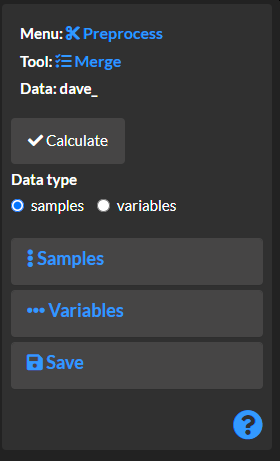

###### Add non-numeric variables to the row meta data.

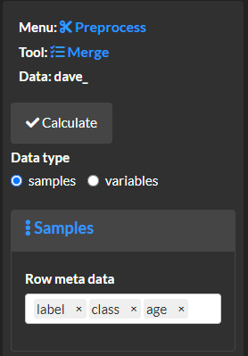

###### Merge the data index with meta data describing the numeric variables (e.g. KEGG and CID identifiers).

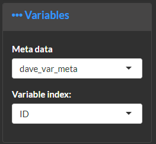

###### Select `calculate` and overview the results.

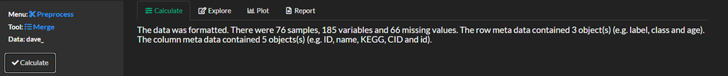

### Explore and plot

###### View the dimensions for the created data assets.

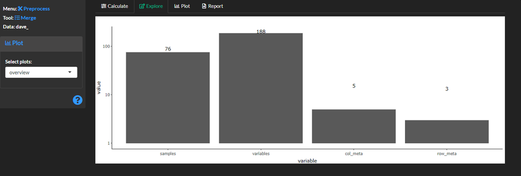

##### Overview missing values for each sample (row) and variable. Connected lines show missing values for the same sample for multiple variables.

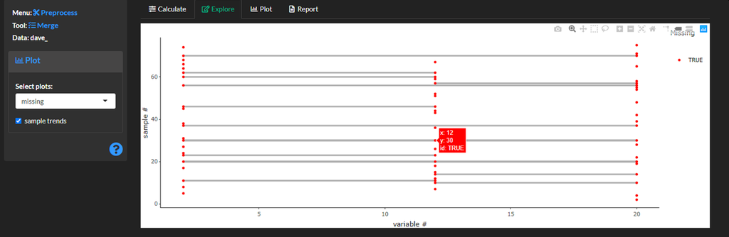

### Report

###### Create a report capturing the methods results and figures.

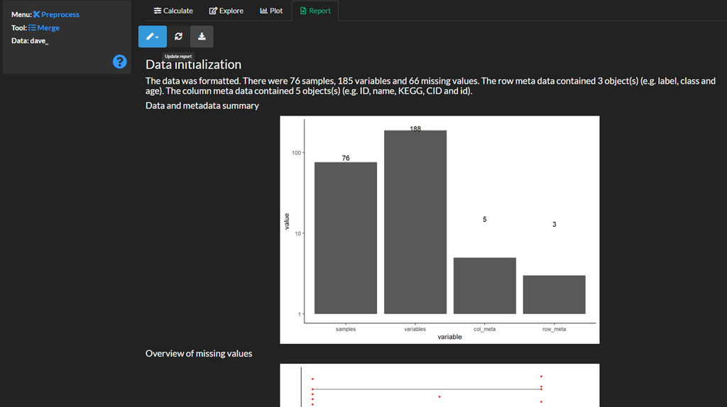

##### Save the results for later analyses.

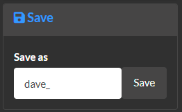

##### The created sample and variable meta data can be viewed in the data menu as `dave__row_meta` and `dave__col_meta`, respectively.

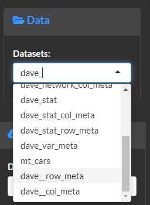

##### From here on every module’s analysis will follow the same basic workflow.

## Missing

### Methods

##### Next remove and/or impute missing values. Use the preprocess >> missing module to remove and/or impute missing values. Note this is an important step to make sure down stream analyses are compatible.

##### Use the filter menu to drop variables which have > greater than the `missing cutoff` percent missing values for a factor of interest, `group`. For examples the example selection will remove any variables which have more than 50% missing values for any levels of the `class` factor.

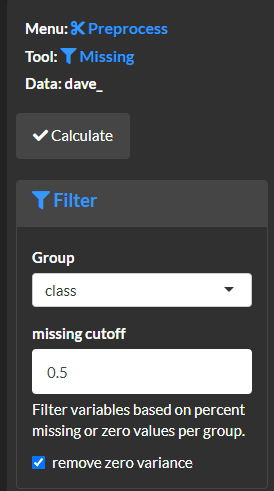

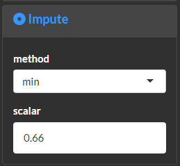

##### Select `calculate` and overview the results.

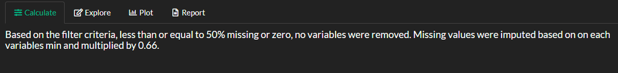

### Explore and plot

##### Review missing values for each row and any removed variables based on the missingness filter.

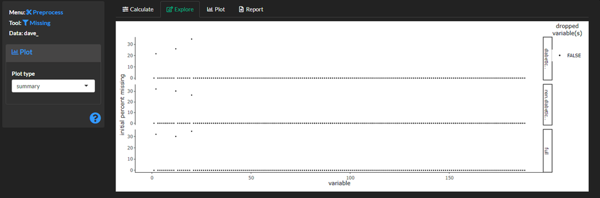

##### Review any remaining missing values in the data.

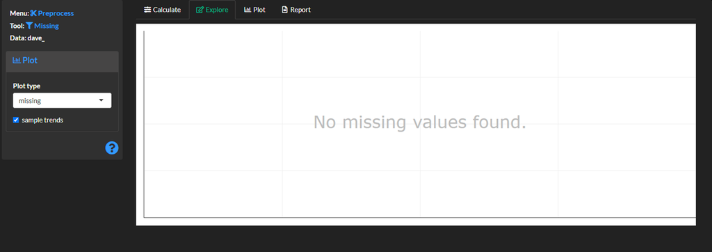

##### Next create a report and save the analysis results.